# Final Project 2016: Development Builds Resilience

# Exploring the Relationship Between the 3 Cs and HDI

When speaking with Derek, he suggested that the Human Development Index might also be a good indicator of hunger as well. Thus we investigated the association between the 3 Cs (both cummulatively and separately) with HDI.

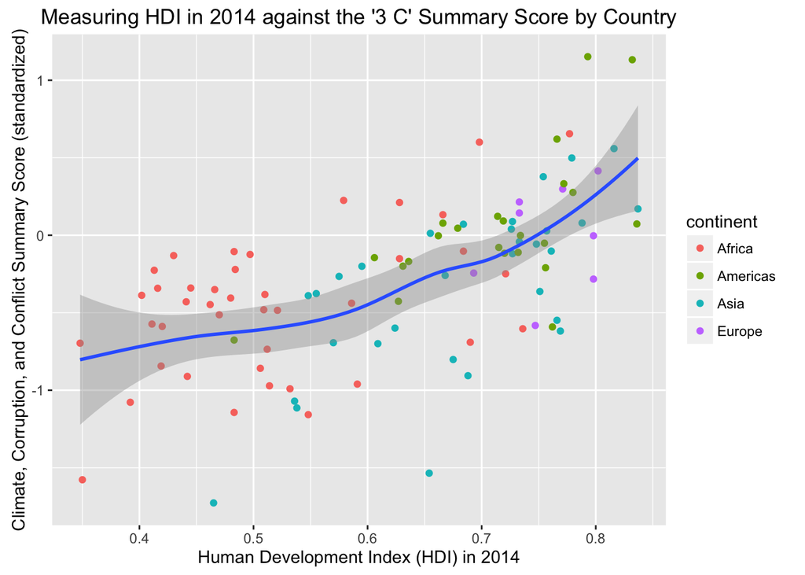

```r
############# Ggplot viz of 3C (summary score) against HDI #######################
hdi_summary <- ggplot(na.omit(df), aes(HDI_2014, Summary_ZScore_2))
hdi_summary + geom_point(aes(color=continent)) +
  labs(title="Measuring HDI in 2014 against the '3 C' Summary Score by Country", x="Human Development Index (HDI) in 2014", y="Climate, Corruption, and Conflict Summary Score (standardized)") + geom_smooth()
```

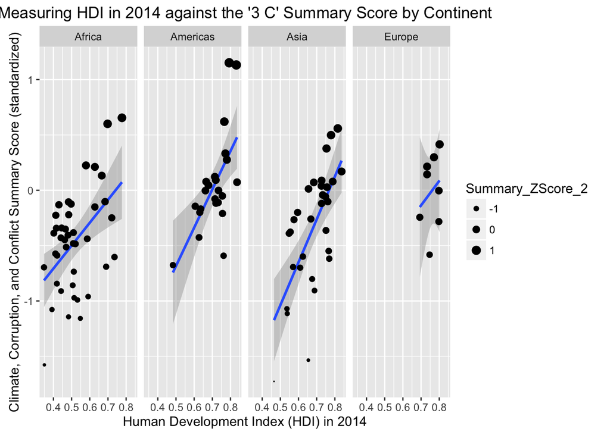

```r
############# Ggplot viz above subset / facet wrapped by continent #######################
hdi_summary + labs(title="Measuring HDI in 2014 against the '3 C' Summary Score by Continent", x="Human Development Index (HDI) in 2014", y="Climate, Corruption, and Conflict Summary Score (standardized)") +
  geom_smooth(method="lm") + facet_grid(~continent) + geom_point(aes(size=Summary_ZScore_2)) + scale_size(range = c(0, 3))
```

```r
############################ Regress 3C against HDI ######################################
fit<-lm(HDI_2014~Summary_ZScore_2,data=na.omit(df))
summary(fit)
```

```
##
## Call:
## lm(formula = HDI_2014 ~ Summary_ZScore_2, data = na.omit(df))
##
## Residuals:
##      Min       1Q   Median       3Q      Max
## -0.22395 -0.07156  0.01388  0.06577  0.22046
##
## Coefficients:
##                  Estimate Std. Error t value Pr(>|t|)
## (Intercept)       0.67204    0.01181  56.926  < 2e-16 ***
## Summary_ZScore_2  0.15537    0.02025   7.672 1.09e-11 ***
## ---
## Signif. codes:  0 '***' 0.001 '**' 0.01 '*' 0.05 '.' 0.1 ' ' 1
##
## Residual standard error: 0.1056 on 101 degrees of freedom
## Multiple R-squared:  0.3682, Adjusted R-squared:  0.3619
## F-statistic: 58.85 on 1 and 101 DF,  p-value: 1.094e-11
```

```r
############### Subset regress 3C against outcome - by continent ###############
library(plyr)
# Break up df by continent, then fit the specified model to each piece and return a list
models <- dlply(na.omit(df), "continent", function(df)
  lm(HDI_2014~Summary_ZScore_2, data = na.omit(df)))
# Apply coef to each model and return a data frame
ldply(models, coef)
```

```
##   continent (Intercept) Summary_ZScore_2
## 1    Africa   0.5731537       0.11710551
## 2  Americas   0.7062658       0.11520454
## 3      Asia   0.7206629       0.11951620
## 4    Europe   0.7595274       0.02984869
```

```r
# Print the summary of each model
l_ply(models, summary, .print = TRUE)
```

```
##
## Call:
## lm(formula = HDI_2014 ~ Summary_ZScore_2, data = na.omit(df))
##
## Residuals:
##      Min       1Q   Median       3Q      Max
## -0.14360 -0.06611 -0.02048  0.06420  0.23349
##
## Coefficients:
##                  Estimate Std. Error t value Pr(>|t|)
## (Intercept)       0.57315    0.02149  26.667  < 2e-16 ***
## Summary_ZScore_2  0.11711    0.03316   3.532  0.00108 **
## ---
## Signif. codes:  0 '***' 0.001 '**' 0.01 '*' 0.05 '.' 0.1 ' ' 1
##
## Residual standard error: 0.09693 on 39 degrees of freedom
## Multiple R-squared:  0.2423, Adjusted R-squared:  0.2229
## F-statistic: 12.47 on 1 and 39 DF,  p-value: 0.001078
##
##
## Call:
## lm(formula = HDI_2014 ~ Summary_ZScore_2, data = na.omit(df))
##
## Residuals:
##       Min        1Q    Median        3Q       Max
## -0.145376 -0.044945 -0.004731  0.033196  0.123880
##
## Coefficients:
##                  Estimate Std. Error t value Pr(>|t|)
## (Intercept)       0.70627    0.01346  52.458  < 2e-16 ***
## Summary_ZScore_2  0.11520    0.03087   3.732  0.00123 **
## ---
## Signif. codes:  0 '***' 0.001 '**' 0.01 '*' 0.05 '.' 0.1 ' ' 1
##
## Residual standard error: 0.06415 on 21 degrees of freedom
## Multiple R-squared:  0.3987, Adjusted R-squared:  0.3701
## F-statistic: 13.93 on 1 and 21 DF,  p-value: 0.001231
##
##
## Call:
```

[output cut: 20 more lines]

```
##
## Residuals:
##       Min        1Q    Median        3Q       Max
## -0.059248 -0.031340  0.003708  0.032206  0.046916
##
## Coefficients:
##                  Estimate Std. Error t value Pr(>|t|)
## (Intercept)       0.75953    0.01456  52.178 3.33e-09 ***
## Summary_ZScore_2  0.02985    0.04586   0.651    0.539
## ---
## Signif. codes:  0 '***' 0.001 '**' 0.01 '*' 0.05 '.' 0.1 ' ' 1
##
## Residual standard error: 0.04117 on 6 degrees of freedom
## Multiple R-squared:  0.06595,    Adjusted R-squared:  -0.08972
## F-statistic: 0.4236 on 1 and 6 DF,  p-value: 0.5392
```

```r
############### Simple regression of 3 variables separately against HDI ###############
fit<-lm(HDI_2014~Corruption_Score+Climate_NominalScore+Average_Conflict, data=na.omit(df))
summary(fit)
```

```
##
## Call:
## lm(formula = HDI_2014 ~ Corruption_Score + Climate_NominalScore +
##     Average_Conflict, data = na.omit(df))
##
## Residuals:
##       Min        1Q    Median        3Q       Max
## -0.112904 -0.039401 -0.001097  0.039453  0.131860
##
## Coefficients:
##                        Estimate Std. Error t value Pr(>|t|)
## (Intercept)           0.0287753  0.0345849   0.832   0.4074
## Corruption_Score     -0.0014048  0.0006372  -2.205   0.0298 *
## Climate_NominalScore  0.0138958  0.0007251  19.165   <2e-16 ***
## Average_Conflict     -0.0013098  0.0031893  -0.411   0.6822
## ---
## Signif. codes:  0 '***' 0.001 '**' 0.01 '*' 0.05 '.' 0.1 ' ' 1
##
## Residual standard error: 0.05645 on 99 degrees of freedom
## Multiple R-squared:  0.8231, Adjusted R-squared:  0.8178
## F-statistic: 153.6 on 3 and 99 DF,  p-value: < 2.2e-16
```

```r
############### Subset regress of 3 vars against outcome - by continent ###############
# Break up df by continent, then fit the specified model to each piece and return a list
models <- dlply(na.omit(df), "continent", function(df)
  lm(HDI_2014~Corruption_Score+Climate_NominalScore+Average_Conflict, data = na.omit(df)))
# Apply coef to each model and return a data frame
ldply(models, coef)
```

```
##   continent (Intercept) Corruption_Score Climate_NominalScore
## 1    Africa -0.09545697     -0.001983983          0.016443747
## 2  Americas  0.07251322     -0.003039407          0.015389542
## 3      Asia  0.18839407      0.001244904          0.008871307
## 4    Europe  0.11257891      0.004681709          0.007743453
##   Average_Conflict
## 1      0.004736524
## 2     -0.011726183
## 3      0.001625350
## 4      0.006141743
```

```r
# Print the summary of each model
l_ply(models, summary, .print = TRUE)
```

```
##
## Call:
## lm(formula = HDI_2014 ~ Corruption_Score + Climate_NominalScore +
##     Average_Conflict, data = na.omit(df))
##
## Residuals:
##       Min        1Q    Median        3Q       Max
## -0.087522 -0.040028 -0.002694  0.031504  0.131372
##
## Coefficients:
##                       Estimate Std. Error t value Pr(>|t|)
## (Intercept)          -0.095457   0.062767  -1.521    0.137
## Corruption_Score     -0.001984   0.001231  -1.612    0.115
## Climate_NominalScore  0.016444   0.001852   8.877 1.06e-10 ***
## Average_Conflict      0.004737   0.005037   0.940    0.353
## ---
## Signif. codes:  0 '***' 0.001 '**' 0.01 '*' 0.05 '.' 0.1 ' ' 1
##
## Residual standard error: 0.05675 on 37 degrees of freedom
## Multiple R-squared:  0.7537, Adjusted R-squared:  0.7337
## F-statistic: 37.73 on 3 and 37 DF,  p-value: 2.402e-11
##
##
## Call:
## lm(formula = HDI_2014 ~ Corruption_Score + Climate_NominalScore +
##     Average_Conflict, data = na.omit(df))
##
## Residuals:
##      Min       1Q   Median       3Q      Max
## -0.07244 -0.01572 -0.00115  0.01390  0.06257
##
## Coefficients:
##                       Estimate Std. Error t value Pr(>|t|)
## (Intercept)           0.072513   0.066347   1.093   0.2881
## Corruption_Score     -0.003039   0.001112  -2.732   0.0132 *
## Climate_NominalScore  0.015390   0.002044   7.530 4.07e-07 ***
## Average_Conflict     -0.011726   0.008407  -1.395   0.1792
## ---
## Signif. codes:  0 '***' 0.001 '**' 0.01 '*' 0.05 '.' 0.1 ' ' 1
##
```

[output cut: 34 more lines]

```
##          7          8
##  0.0028233  0.0191539
##
## Coefficients:
##                      Estimate Std. Error t value Pr(>|t|)
## (Intercept)          0.112579   0.125944   0.894  0.42191
## Corruption_Score     0.004682   0.002638   1.774  0.15066
## Climate_NominalScore 0.007743   0.001487   5.208  0.00648 **
## Average_Conflict     0.006142   0.008584   0.716  0.51384
## ---
## Signif. codes:  0 '***' 0.001 '**' 0.01 '*' 0.05 '.' 0.1 ' ' 1
##
## Residual standard error: 0.01573 on 4 degrees of freedom
## Multiple R-squared:  0.9091, Adjusted R-squared:  0.8409
## F-statistic: 13.33 on 3 and 4 DF,  p-value: 0.01502
```

```r
############### Toying with Summary Score ###############
#Summary Score is still a significant predictor of HDI, once you remove Climate
fit<-lm(HDI_2014~Summary_ZScore_3,data=na.omit(df))
summary(fit)
```

```
##
## Call:
## lm(formula = HDI_2014 ~ Summary_ZScore_3, data = na.omit(df))
##
## Residuals:
##      Min       1Q   Median       3Q      Max
## -0.26953 -0.09190  0.01552  0.10406  0.21616
##
## Coefficients:
##                  Estimate Std. Error t value Pr(>|t|)
## (Intercept)       0.64316    0.01342  47.910   <2e-16 ***
## Summary_ZScore_3  0.06355    0.02164   2.937   0.0041 **
## ---
## Signif. codes:  0 '***' 0.001 '**' 0.01 '*' 0.05 '.' 0.1 ' ' 1
##
## Residual standard error: 0.1276 on 101 degrees of freedom
## Multiple R-squared:  0.0787, Adjusted R-squared:  0.06958
## F-statistic: 8.628 on 1 and 101 DF,  p-value: 0.004101
```

```r
#Summary Score is still a significant predictor of HDI, even when Corruption is removed
fit<-lm(HDI_2014~Summary_ZScore_4,data=na.omit(df))
summary(fit)
```

```
##
## Call:
## lm(formula = HDI_2014 ~ Summary_ZScore_4, data = na.omit(df))
##
## Residuals:
##       Min        1Q    Median        3Q       Max
## -0.244431 -0.075053  0.008092  0.065111  0.225472
##
## Coefficients:
##                  Estimate Std. Error t value Pr(>|t|)
## (Intercept)       0.65759    0.01094  60.086  < 2e-16 ***
## Summary_ZScore_4  0.13953    0.01782   7.829 5.04e-12 ***
## ---
## Signif. codes:  0 '***' 0.001 '**' 0.01 '*' 0.05 '.' 0.1 ' ' 1
##
## Residual standard error: 0.1048 on 101 degrees of freedom
## Multiple R-squared:  0.3776, Adjusted R-squared:  0.3715
## F-statistic: 61.29 on 1 and 101 DF,  p-value: 5.039e-12
```

```r
#Summary Score is still a significant predictor of HDI, even when Conflict is removed
fit<-lm(HDI_2014~Summary_ZScore_5,data=na.omit(df))
summary(fit)
```

```
##
## Call:
## lm(formula = HDI_2014 ~ Summary_ZScore_5, data = na.omit(df))
##
## Residuals:
##      Min       1Q   Median       3Q      Max
## -0.20847 -0.04652  0.01683  0.05307  0.20380
##
## Coefficients:
##                  Estimate Std. Error t value Pr(>|t|)
## (Intercept)       0.70611    0.01036   68.18   <2e-16 ***
## Summary_ZScore_5  0.18989    0.01540   12.33   <2e-16 ***
## ---
## Signif. codes:  0 '***' 0.001 '**' 0.01 '*' 0.05 '.' 0.1 ' ' 1
##
## Residual standard error: 0.08397 on 101 degrees of freedom
## Multiple R-squared:  0.6008, Adjusted R-squared:  0.5968
## F-statistic:   152 on 1 and 101 DF,  p-value: < 2.2e-16
```

When we regress HDI against the three 3Cs we find the coefficient of the 3Cs is statistically significant at the 0.05 alpha level. There is a positive association between these variables.

When we regress HDI against the three 3Cs on a per-continent basis we find that the coefficient is significant for all continents except for Europe. We believe that this is due to the small number of countries for which we have data on this continent. For all continents there is a positive association between these variables.

When we do a regression of corruption, climate, and conflict as separate predictors for HDI, we find that both corruption and climate are statistically significant. There is a positive association between HDI and climate and a negative association between HDI and corruption.

When we regress HDI against the three 3Cs separately on a per-continent basis we find that the coefficient for climate is significant for all continents whereas the others are not (apart from corruption in the Americas). Finding that climate is the most important predictor of HDI is kinda surprising but also kinda cool!

When the summary score only consists of Conflict and Corruption, it still significantly predicts HDI. Similarly, when you consider Climate and Corruption or Climate and Conflict and HDI, the summary score is still a significant predictor. Although the effects estimates are strongest when Climate is still included in the summary score, these results also suggest that conflict and corruption may have a synergistic effect on HDI.

# Exploring the Relationship Between the 3 Cs and GDP

When speaking with Derek, he suggested that the GDP might also be a good indicator of hunger as well. Thus we investigated the association between the 3 Cs (both cummulatively and separately) with GDP.

There are several ways to measure GDP. We used the GDP measure based on purchasing power parity (PPP) which allows one to make more accurate comparisons of the economies of two countries. In short, it is calculated by determining what each item purchased in a country would cost if it were sold in the international currency and then these are added up for all the final goods and services produced in that country for that given year.

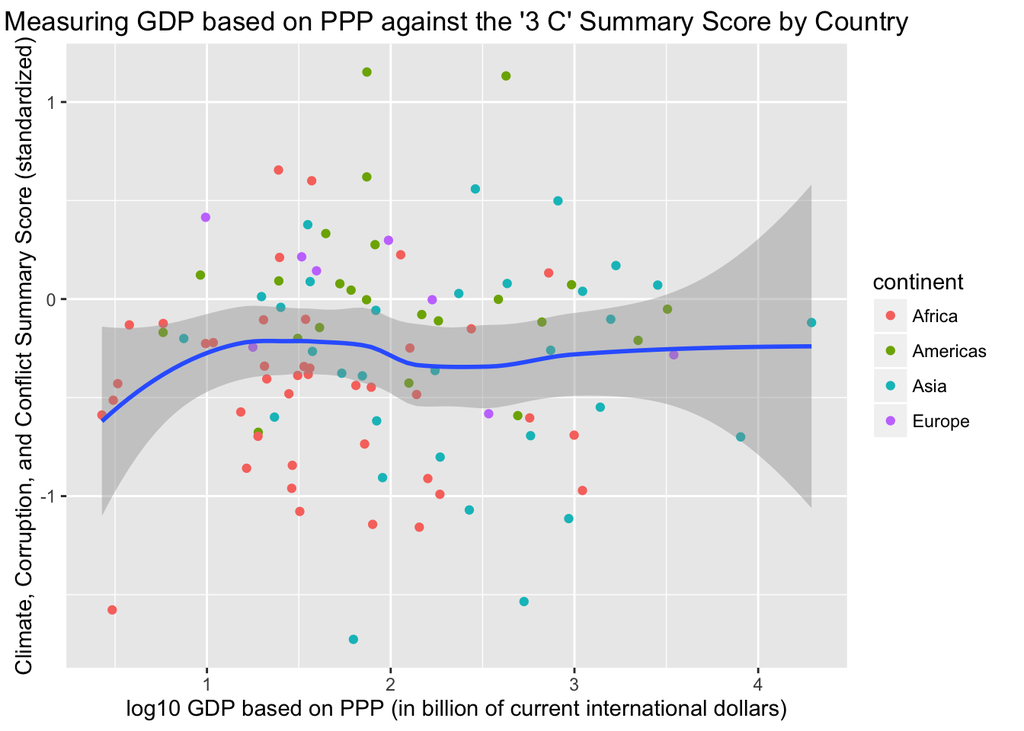

```r
############# Ggplot viz of 3C (summary score) against GDP ##########
# Plot GDP against summary score
gdp_summary <- ggplot(na.omit(df), aes(log10(GDP), Summary_ZScore_2))
gdp_summary + geom_point(aes(color=continent)) +
  labs(title="Measuring GDP based on PPP against the '3 C' Summary Score by Country", x="log10 GDP based on PPP (in billion of current international dollars)", y="Climate, Corruption, and Conflict Summary Score (standardized)") + geom_smooth()
```

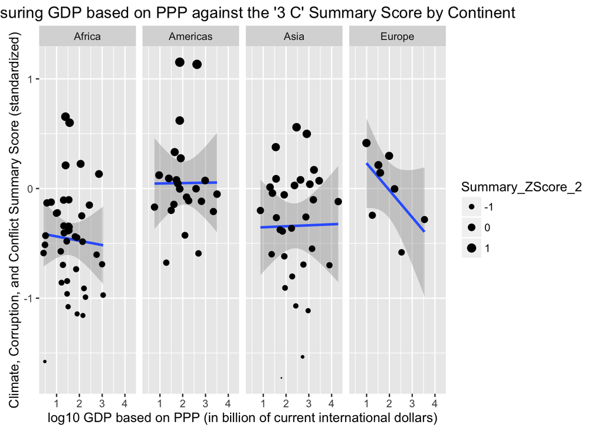

```r
############# Ggplot viz above subset / facet wrapped by continent ##########
gdp_summary + labs(title="Measuring GDP based on PPP against the '3 C' Summary Score by Continent", x="log10 GDP based on PPP (in billion of current international dollars)", y="Climate, Corruption, and Conflict Summary Score (standardized)") +
  geom_smooth(method="lm") + facet_grid(~continent) + geom_point(aes(size=Summary_ZScore_2)) + scale_size(range = c(0, 3))
```

```r
############################ Regress 3C against GDP #################
fit<-lm(log10(GDP)~Summary_ZScore_2,data=na.omit(df))
summary(fit)
```

```
##
## Call:
## lm(formula = log10(GDP) ~ Summary_ZScore_2, data = na.omit(df))
##
## Residuals:
##     Min      1Q  Median      3Q     Max
## -1.5207 -0.5369 -0.1103  0.5404  2.3244
##
## Coefficients:
##                  Estimate Std. Error t value Pr(>|t|)
## (Intercept)       1.97023    0.08961  21.986   <2e-16 ***
## Summary_ZScore_2  0.03643    0.15373   0.237    0.813
## ---
## Signif. codes:  0 '***' 0.001 '**' 0.01 '*' 0.05 '.' 0.1 ' ' 1
##
## Residual standard error: 0.8019 on 101 degrees of freedom
## Multiple R-squared:  0.0005556,  Adjusted R-squared:  -0.00934
## F-statistic: 0.05615 on 1 and 101 DF,  p-value: 0.8132
```

```r
############### Subset regress 3C against outcome - by continent ###############
library(plyr)
# Break up df by continent, then fit the specified model to each piece and return a list
models <- dlply(na.omit(df), "continent", function(df)
  lm(log10(GDP)~Summary_ZScore_2, data = na.omit(df)))
# Apply coef to each model and return a data frame
ldply(models, coef)
```

```
##   continent (Intercept) Summary_ZScore_2
## 1    Africa    1.554023     -0.083691961
## 2  Americas    2.054860      0.009070385
## 3      Asia    2.383904      0.019611679
## 4    Europe    1.947994     -1.426556561
```

```r
# Print the summary of each model
l_ply(models, summary, .print = TRUE)
```

```
##
## Call:
## lm(formula = log10(GDP) ~ Summary_ZScore_2, data = na.omit(df))
##
## Residuals:
##      Min       1Q   Median       3Q      Max
## -1.20174 -0.33447 -0.09259  0.50458  1.40816
##
## Coefficients:
##                  Estimate Std. Error t value Pr(>|t|)
## (Intercept)       1.55402    0.15096  10.294 1.12e-12 ***
## Summary_ZScore_2 -0.08369    0.23288  -0.359    0.721
## ---
## Signif. codes:  0 '***' 0.001 '**' 0.01 '*' 0.05 '.' 0.1 ' ' 1
##
## Residual standard error: 0.6808 on 39 degrees of freedom
## Multiple R-squared:  0.003301,   Adjusted R-squared:  -0.02226
## F-statistic: 0.1291 on 1 and 39 DF,  p-value: 0.7213
##
##
## Call:
## lm(formula = log10(GDP) ~ Summary_ZScore_2, data = na.omit(df))
##
## Residuals:
##     Min      1Q  Median      3Q     Max
## -1.2921 -0.4260 -0.1863  0.5468  1.4518
##
## Coefficients:
##                  Estimate Std. Error t value Pr(>|t|)
## (Intercept)       2.05486    0.15320  13.413  9.1e-12 ***
## Summary_ZScore_2  0.00907    0.35127   0.026     0.98
## ---
## Signif. codes:  0 '***' 0.001 '**' 0.01 '*' 0.05 '.' 0.1 ' ' 1
##
## Residual standard error: 0.7299 on 21 degrees of freedom
## Multiple R-squared:  3.175e-05,  Adjusted R-squared:  -0.04759
## F-statistic: 0.0006668 on 1 and 21 DF,  p-value: 0.9796
##
##
## Call:
```

[output cut: 20 more lines]

```
##
## Residuals:
##     Min      1Q  Median      3Q     Max
## -1.0459 -0.2745 -0.1369  0.3213  1.1893
##
## Coefficients:
##                  Estimate Std. Error t value Pr(>|t|)
## (Intercept)        1.9480     0.2512   7.753 0.000242 ***
## Summary_ZScore_2  -1.4266     0.7915  -1.802 0.121575
## ---
## Signif. codes:  0 '***' 0.001 '**' 0.01 '*' 0.05 '.' 0.1 ' ' 1
##
## Residual standard error: 0.7105 on 6 degrees of freedom
## Multiple R-squared:  0.3512, Adjusted R-squared:  0.2431
## F-statistic: 3.248 on 1 and 6 DF,  p-value: 0.1216
```

```r
############### Simple regression of 3 variables separately against GDP ##########
fit<-lm(log10(GDP)~Corruption_Score+Climate_NominalScore+Average_Conflict, data=na.omit(df))
summary(fit)
```

```
##
## Call:
## lm(formula = log10(GDP) ~ Corruption_Score + Climate_NominalScore +
##     Average_Conflict, data = na.omit(df))
##
## Residuals:
##      Min       1Q   Median       3Q      Max
## -1.47750 -0.33169 -0.00939  0.33479  1.62880
##
## Coefficients:
##                       Estimate Std. Error t value Pr(>|t|)
## (Intercept)          -1.063715   0.364424  -2.919  0.00435 **
## Corruption_Score     -0.005840   0.006714  -0.870  0.38652
## Climate_NominalScore  0.051948   0.007640   6.799 8.03e-10 ***
## Average_Conflict      0.192273   0.033606   5.721 1.13e-07 ***
## ---
## Signif. codes:  0 '***' 0.001 '**' 0.01 '*' 0.05 '.' 0.1 ' ' 1
##
## Residual standard error: 0.5948 on 99 degrees of freedom
## Multiple R-squared:  0.4609, Adjusted R-squared:  0.4446
## F-statistic: 28.21 on 3 and 99 DF,  p-value: 2.863e-13
```

```r
############### Subset regress of 3 vars against outcome - by continent ###############
# Break up df by continent, then fit the specified model to each piece and return a list
models <- dlply(na.omit(df), "continent", function(df)
  lm(log10(GDP)~Corruption_Score+Climate_NominalScore+Average_Conflict, data = na.omit(df)))
# Apply coef to each model and return a data frame
ldply(models, coef)
```

```
##   continent (Intercept) Corruption_Score Climate_NominalScore
## 1    Africa  -1.6487313      -0.02514578           0.08478926
## 2  Americas  -2.3020870      -0.01242987           0.07366340
## 3      Asia  -0.2986975       0.01905335           0.02301424
## 4    Europe  -0.8751592      -0.07562789           0.09139228
##   Average_Conflict
## 1       0.16365062
## 2       0.37466972
## 3       0.19071136
## 4       0.01702801
```

```r
# Print the summary of each model
l_ply(models, summary, .print = TRUE)
```

```
##
## Call:
## lm(formula = log10(GDP) ~ Corruption_Score + Climate_NominalScore +
##     Average_Conflict, data = na.omit(df))
##
## Residuals:
##      Min       1Q   Median       3Q      Max
## -1.13430 -0.16099  0.04838  0.24389  1.04461
##
## Coefficients:
##                      Estimate Std. Error t value Pr(>|t|)
## (Intercept)          -1.64873    0.49980  -3.299  0.00215 **
## Corruption_Score     -0.02515    0.00980  -2.566  0.01448 *
## Climate_NominalScore  0.08479    0.01475   5.748 1.38e-06 ***
## Average_Conflict      0.16365    0.04011   4.080  0.00023 ***
## ---
## Signif. codes:  0 '***' 0.001 '**' 0.01 '*' 0.05 '.' 0.1 ' ' 1
##
## Residual standard error: 0.4519 on 37 degrees of freedom
## Multiple R-squared:  0.5835, Adjusted R-squared:  0.5497
## F-statistic: 17.28 on 3 and 37 DF,  p-value: 3.538e-07
##
##
## Call:
## lm(formula = log10(GDP) ~ Corruption_Score + Climate_NominalScore +
##     Average_Conflict, data = na.omit(df))
##
## Residuals:
##      Min       1Q   Median       3Q      Max
## -0.74828 -0.22022 -0.00333  0.24115  0.73392
##
## Coefficients:
##                      Estimate Std. Error t value Pr(>|t|)
## (Intercept)          -2.30209    0.84293  -2.731  0.01327 *
## Corruption_Score     -0.01243    0.01413  -0.880  0.39010
## Climate_NominalScore  0.07366    0.02597   2.837  0.01054 *
## Average_Conflict      0.37467    0.10681   3.508  0.00235 **
## ---
## Signif. codes:  0 '***' 0.001 '**' 0.01 '*' 0.05 '.' 0.1 ' ' 1
##
```

[output cut: 30 more lines]

```
##
## Residuals:
##        1        2        3        4        5        6        7        8
## -0.07007 -0.49737  0.32326 -0.39600 -0.32261  0.37954  0.51253  0.07072
##
## Coefficients:
##                      Estimate Std. Error t value Pr(>|t|)
## (Intercept)          -0.87516    4.06191  -0.215    0.840
## Corruption_Score     -0.07563    0.08509  -0.889    0.424
## Climate_NominalScore  0.09139    0.04796   1.906    0.129
## Average_Conflict      0.01703    0.27684   0.062    0.954
##
## Residual standard error: 0.5073 on 4 degrees of freedom
## Multiple R-squared:  0.7795, Adjusted R-squared:  0.6142
## F-statistic: 4.714 on 3 and 4 DF,  p-value: 0.08414
```

For all of the GDP analysis we use the log10 transformation for GDP. This is due to the non-normality of this data.

When we regress GDP against the three 3Cs we find the coefficient of the 3Cs is not statistically significant at the 0.05 alpha level, suggesting that the 3Cs summary measure is not predictive of GDP.

When we do a regression of corruption, climate, and conflict as separate predictors for GDP, we find that both conflict and climate are statistically significant. There is a positive association between GDP and climate as well as with conflict.

When we regress GDP against the three 3Cs separately on a per-continent basis we find the following: For Africa and the Americas, both conflict and climate have a statistically significant positive association with GDP. For Asia conflict has a statistically significant positive association with GDP. For Europe we find that none of the Cs has a statistically significant association with GDP.

When we toy with the summary score we find that the summary score is not a significant predictor of GDP when corruption is removed. But it is still a significant predictor of GDP when you remove either conflict or climate is removed. This suggests that corruption has a synergistic effect on GDP.

```r
############### Toying with Summary Score ###############
#Summary Score is a significant predictor of GDP, once you remove Climate
fit<-lm(log10(GDP)~Summary_ZScore_3,data=na.omit(df))
summary(fit)
```

```
##
## Call:
## lm(formula = log10(GDP) ~ Summary_ZScore_3, data = na.omit(df))
##
## Residuals:
##     Min      1Q  Median      3Q     Max
## -1.9155 -0.5362 -0.1000  0.5123  2.2493
##
## Coefficients:
##                  Estimate Std. Error t value Pr(>|t|)
## (Intercept)       1.88567    0.08172  23.074   <2e-16 ***
## Summary_ZScore_3 -0.34214    0.13171  -2.598   0.0108 *
## ---
## Signif. codes:  0 '***' 0.001 '**' 0.01 '*' 0.05 '.' 0.1 ' ' 1
##
## Residual standard error: 0.7766 on 101 degrees of freedom
## Multiple R-squared:  0.06262,    Adjusted R-squared:  0.05334
## F-statistic: 6.748 on 1 and 101 DF,  p-value: 0.01079
```

```r
#Summary Score is not a significant predictor of GDP, even when Corruption is removed
fit<-lm(log10(GDP)~Summary_ZScore_4,data=na.omit(df))
summary(fit)
```

```
##
## Call:
## lm(formula = log10(GDP) ~ Summary_ZScore_4, data = na.omit(df))
##
## Residuals:
##      Min       1Q   Median       3Q      Max
## -1.53234 -0.53534 -0.08922  0.53854  2.33102
##
## Coefficients:
##                   Estimate Std. Error t value Pr(>|t|)
## (Intercept)       1.958996   0.083727  23.397   <2e-16 ***
## Summary_ZScore_4 -0.006011   0.136353  -0.044    0.965
## ---
## Signif. codes:  0 '***' 0.001 '**' 0.01 '*' 0.05 '.' 0.1 ' ' 1
##
## Residual standard error: 0.8021 on 101 degrees of freedom
## Multiple R-squared:  1.924e-05,  Adjusted R-squared:  -0.009882
## F-statistic: 0.001944 on 1 and 101 DF,  p-value: 0.9649
```

```r
#Summary Score is a significant predictor of GDP when Conflict is removed
fit<-lm(log10(GDP)~Summary_ZScore_5,data=na.omit(df))
summary(fit)
```

```
##
## Call:
## lm(formula = log10(GDP) ~ Summary_ZScore_5, data = na.omit(df))
##
## Residuals:
##     Min      1Q  Median      3Q     Max
## -1.3332 -0.5290 -0.1065  0.4756  2.0556
##
## Coefficients:
##                  Estimate Std. Error t value Pr(>|t|)
## (Intercept)       2.16534    0.09293   23.30  < 2e-16 ***
## Summary_ZScore_5  0.50720    0.13820    3.67 0.000389 ***
## ---
## Signif. codes:  0 '***' 0.001 '**' 0.01 '*' 0.05 '.' 0.1 ' ' 1
##
## Residual standard error: 0.7534 on 101 degrees of freedom
## Multiple R-squared:  0.1177, Adjusted R-squared:  0.1089
## F-statistic: 13.47 on 1 and 101 DF,  p-value: 0.0003894
```

# Final Analysis